# Лабораторная работа 1

Проверка следующих навыков: Манипулирование объектами данных; использование встроенных функций; построение простейших графиков; простейшие статистические концепции. ## Требования к оформлению * Оформить решение в R Markdown. * Сохранить файл в свой репозиторий. * Выгрузить R Markdown в HTML, назвать своим именем и отправить по почте (если хочется сдать раньше или нужна помощь).

## Исходные данные

Экспоненциальное распределение определяется следующей функцией распределения:

```
F(x) = 1 - e^(-λ⋅x)
```

Функция `rexp` генерирует случайные переменные при помощи экспоненциального распределения `rexp(n=42, rate=5)` вернёт 42 экспоненциально-распределённых числа с параметром (λ) равным 5. Ели второй аргумент не указан, будет использовано значение 1 т.е. получим “стандартное экспоненциальное распределение”.

## Задание 1

1. Сгенерируйте 200 случайных значений из стандартного экспоненциального распределения и сохраните в вектор *exp.1*. Найдите среднее и стандартное отклонение из данных этого вектора.

```r
lambda <- as.integer(5)
sampleLength <- as.integer(200)

exp.1 <- rexp(sampleLength)
mean <- mean(exp.1)
standartDev <-  sd(exp.1)
```

2. Повторите, использовав следующие значения параметра λ: 0.1, 0.5, 5, 10, и сохраните результаты в векторы: *exp.0.1*, *exp.0.5*, *exp.5*, *exp.10*.

```r
exp.0.1 <- rexp(sampleLength, rate = 0.1)
exp.0.5 <- rexp(sampleLength, rate = 0.5)
exp.5 <- rexp(sampleLength, rate = 5)
exp.10 <- rexp(sampleLength, rate = 10)
```

3. Функция `plot()` общая функция для визуализации данных. Функция `hist()` принимает данные и раскладывает их по корзинам. Чтобы использовать эти функции нужно для начала передать им данные, которые хотим визуализировать.
4. Используйте функцию `hist()` для построения гистограммы полученного ранее стандартного распределения.
5. Используйте функцию `plot()` с тем же самым вектором для построения графика значений в порядке следования.
6. Используйте функцию `plot()` с любыми двумя полученными ранее векторами, чтобы получить диаграмму рассеяния ([scatterplot](https://www.mathsisfun.com/data/scatter-xy-plots.html)) этих векторов относительно друг друга.

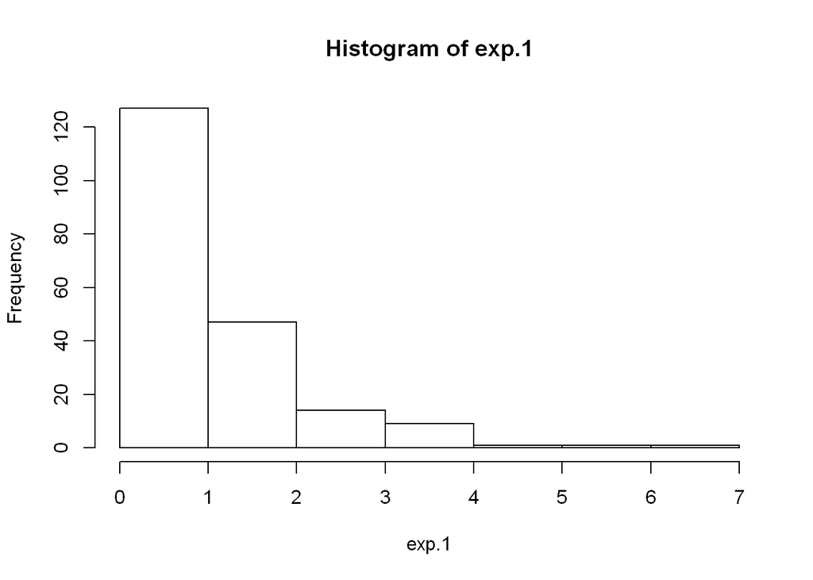

```r
hist(exp.1)
```

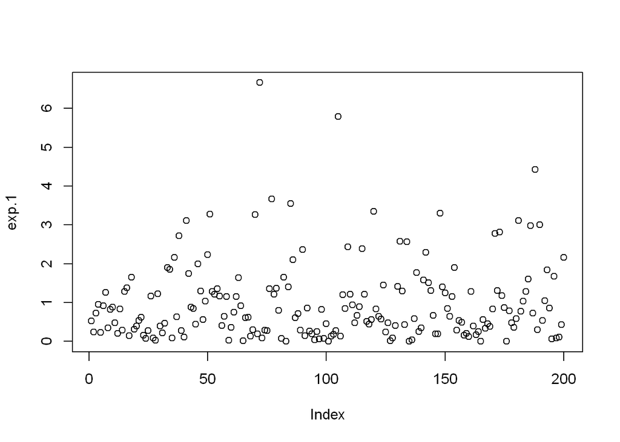

```r
plot(exp.1)
```

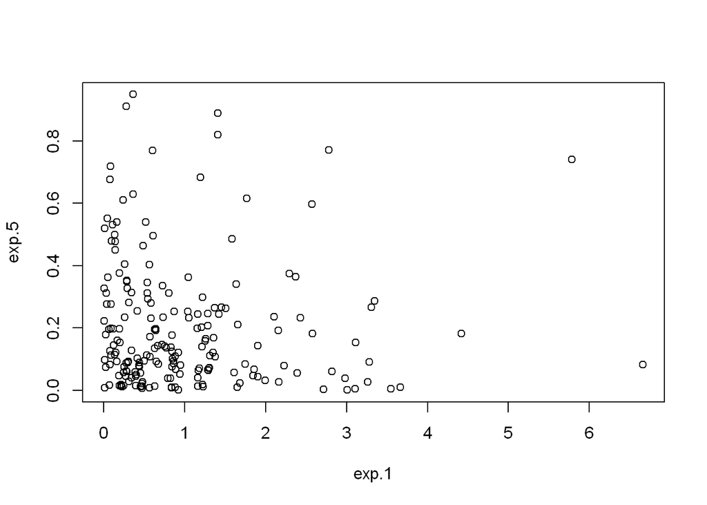

```r
plot(exp.1, exp.5)
```

4. Теперь сравним свойства всех наших векторов. Для начала создадим вектор, содержащий средние значения каждого из 5 полученных ранее распределений в порядке их создания. Полученный вектор сохраним в переменную *exp.means*. Далее необходимо создать следующие диаграммы рассеяния:
5. Вектор с пятью средними относительно каждого из пяти векторов с различными значениями λ.
6. Вектор с пятью стандартными отклонениями относительно каждого из пяти векторов с различными значениями λ.
7. Вектор с пятью средними относительно вектора с пятью стандартными отклонениями.

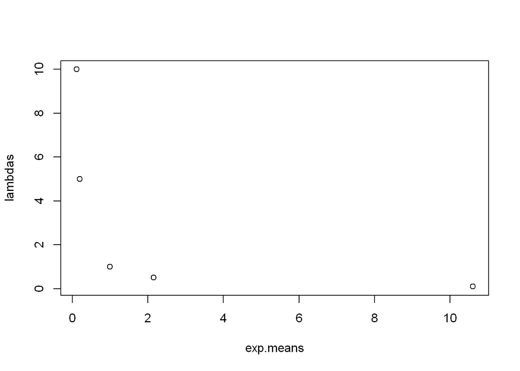

```r
lambdas <-c(1, 0.1, 0.5, 5, 10)
exp.means <- c(mean(exp.1), mean(exp.0.1), mean(exp.0.5), mean(exp.5), mean(exp.10))
exp.sds <- c(sd(exp.1), sd(exp.0.1), sd(exp.0.5), sd(exp.5), sd(exp.10))
plot(exp.means, lambdas)
```

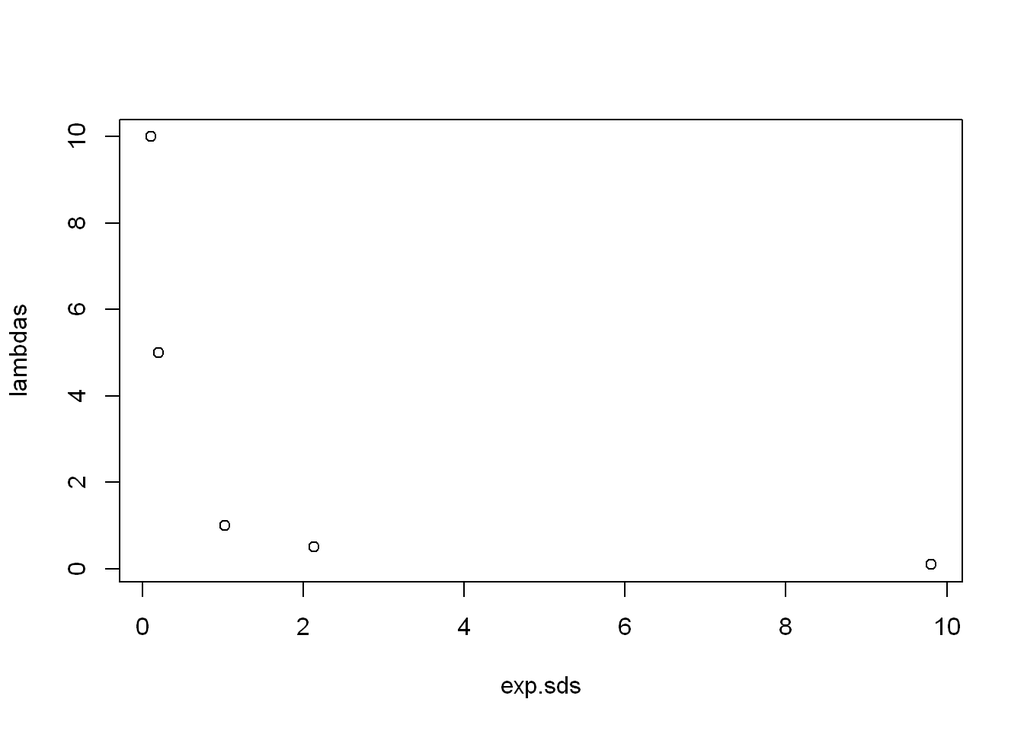

```r
plot(exp.sds, lambdas)
```

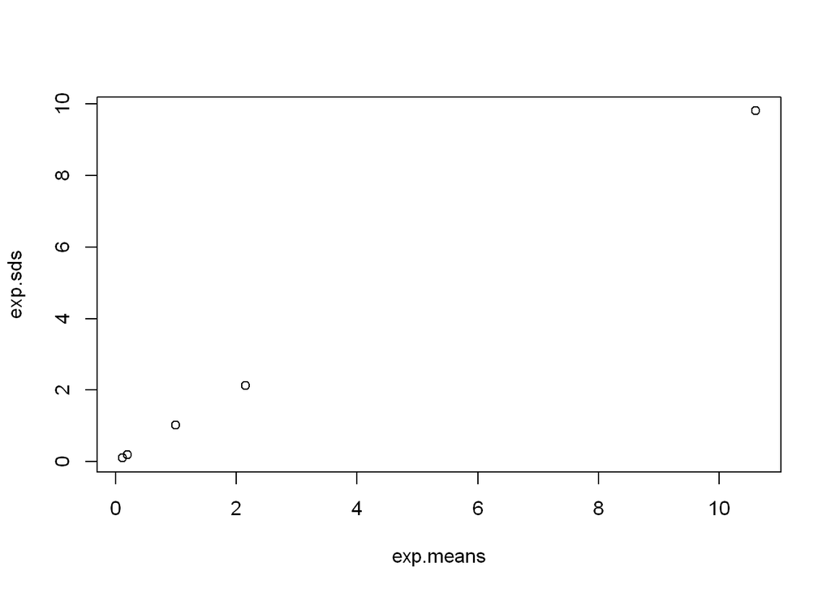

```r
plot(exp.means, exp.sds)
```

## Задание 2

R достаточно производителен, чтобы вычислять относительно большие объёмы данных.

- Для демонстрации сгенерируйте 1100000 (1 млн. 100 тысяч) чисел из стандартного экспоненциального распределения и сохраните их в вектор *huge.exp.1*. Получите среднее и стандартное отклонение.
- Получите гистограмму *huge.exp.1*. Она соответствует функции `1 - e:^(-x)`? Должна ли?
- Получите среднее всех чисел из *huge.exp.1* строго больших 1. Для проверки выборки может потребоваться новый вектор.
- Получите матрицу *huge.exp.1.mat*, содержащую 1100 строк и 1000 колонок. Постройте гистограмму, использовав полученную матрицу. Что можно сказать о полученных данных?
- Рассчитайте среднее 137-й колонки из *huge.exp.1.mat*.
- Найдите среднее всей 1000 колонок и сохраните их в вектор. Отобразите диаграмму средних значений колонок. Объясните почему форма диаграммы отличается от виденных ранее.
- Рассчитайте квадрат каждого значения из *huge.exp.1* и найдите среднее и стандартное отклонение полученного вектора квадратов. Объясните отличие от соответствующих показателей вектора *huge.exp.1*. Вам может помочь формула, по которой R рассчитывает стандартное отклонение: `sqrt(sum((x - mean(x))^2) / (n - 1))`.

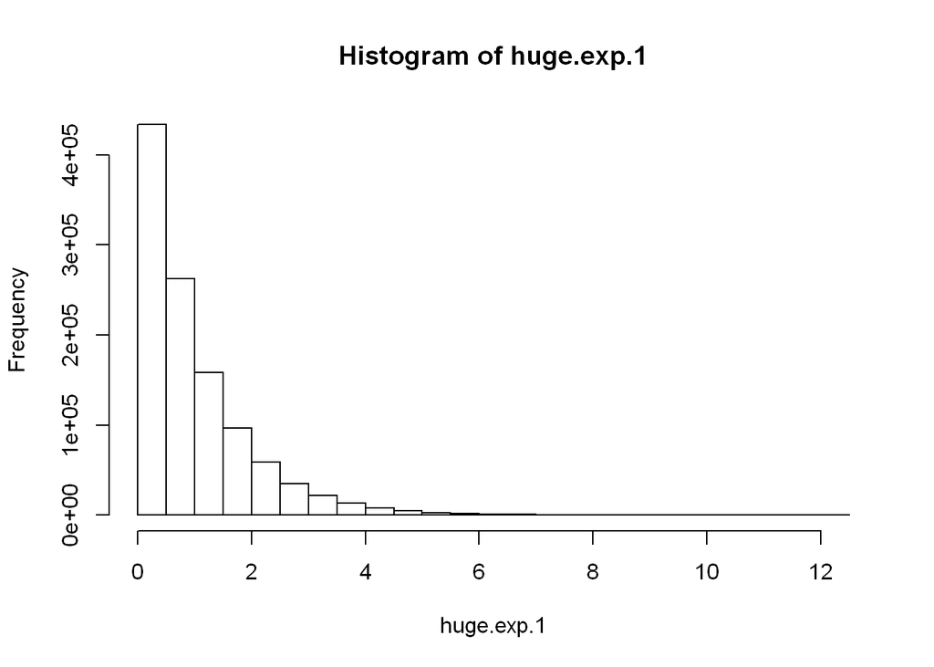

```r
huge.exp.1 <- rexp(1100000, 1)
huge.mean <- mean(huge.exp.1)   #0.999
huge.sd <- sd(huge.exp.1)   #1.001
hist(huge.exp.1)
```

Данная гистограмма не соответсвует экспоненциальному распределению, т.к. не нормализована.

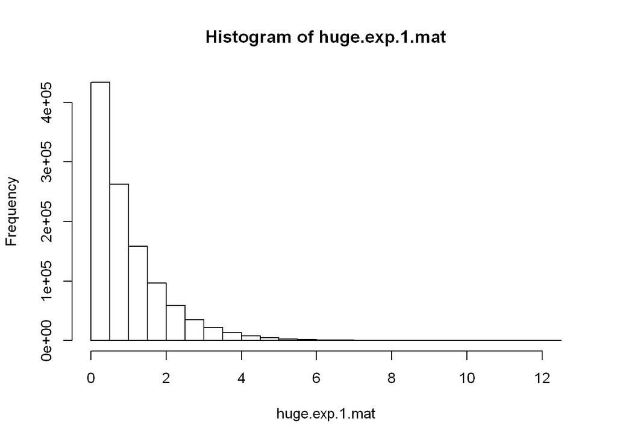

```r
mean.bigger.than.one <- mean(huge.exp.1[huge.exp.1 > 1])    #2.001
huge.exp.1.mat <- matrix(huge.exp.1, 1100, 1000)
hist(huge.exp.1.mat)
```

Данные те же => гистограмма аналогична пердыдущей.

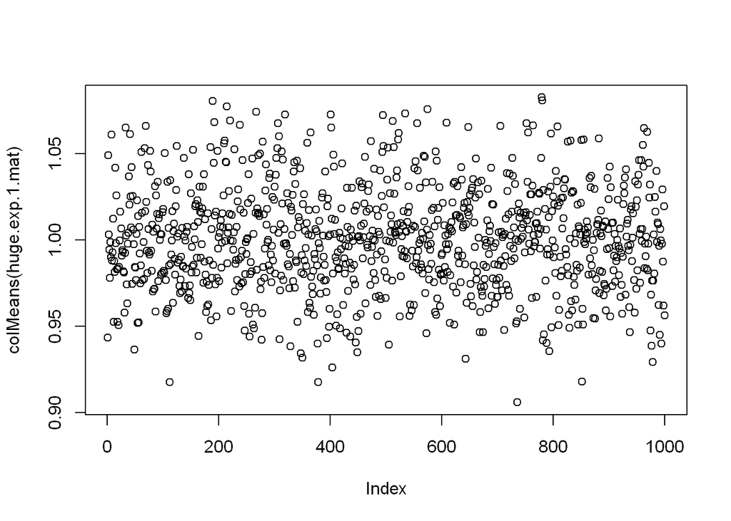

```r
mean.137 <- mean(huge.exp.1.mat[,137])    # 1.01087
plot(colMeans(huge.exp.1.mat))
```

На этом графике отображается среднее значение по каждой колонке. Так как данные не отсортированы, нельзя увидить никакого тренда, однако все значения лежат в каких-то разумных пределах, на что указывает трубовидность графика.

```r
square.mean <- mean(huge.exp.1 ^ 2)   # 2.000
square.sd <- sd(huge.exp.1 ^ 2)   #4.489
```